# Challenges

This routine will include some of the challenges that were posted each week but that I haven’t really tried until now.

Jason O’Connell  
2022-03-20

## Initialize Libraries

```r
library(tidyverse)
library(readr)
library(readxl)
library(dplyr)
library(ggplot2)
```

Challenges:

- Create your first Rpubs or github distill post. Advanced: publish a personal distill blog using github pages.

I have now created a personal blog for DACSS 601 on Github and will keep all posts here!

- Read in clean data; (intermediate) read in uncleaned railroad data; read in uncleaned australian marriage data; (additional) install tex and try knitting to pd; try using dbconnect to read in data from sql;

```r
rr_county <- read.csv("_data/Clean/railroad_2012_clean_county_tidy.csv")
rr_state <- read.csv("_data/Clean/railroad_2012_clean_state.csv")
aussie_marriage <- read_excel("_data/Unclean/australian_marriage_law_postal_survey_2017_-_response_final.xls", sheet = "Table 2", na = "", skip = 6) %>%
  select(1:2,4,9,11,13) %>%
  rename(town = 1, "response_clear:yes" = 2, "response_clear:no" = 3, "eligible:yes" = 4, "eligible:no" = 5, "eligible:noresponse" = 6) %>%
  filter(str_detect(town, "Divisions", negate=TRUE), str_detect(town, "(Total)", negate=TRUE)) %>%
  pivot_longer(cols = 2:6, names_to = "temp") %>%
  separate(temp, into = c("q","r"), sep = ":")


head(rr_county)
```

```
  state               county total_employees
1    AE                  APO               2
2    AK            ANCHORAGE               7
3    AK FAIRBANKS NORTH STAR               2
4    AK               JUNEAU               3
5    AK    MATANUSKA-SUSITNA               2
6    AK                SITKA               1
```

```r
head(rr_state)
```

```
  state total_employees
1    AE               2
2    AK             103
3    AL            4257
4    AP               1
5    AR            3871
6    AZ            3153
```

```r
head(aussie_marriage)
```

```
# A tibble: 6 x 4
  town   q              r          value
  <chr>  <chr>          <chr>      <dbl>
1 Banks  response_clear yes        37736
2 Banks  response_clear no         46343
3 Banks  eligible       yes        84079
4 Banks  eligible       no           247
5 Banks  eligible       noresponse 20928
6 Barton response_clear yes        37153
```

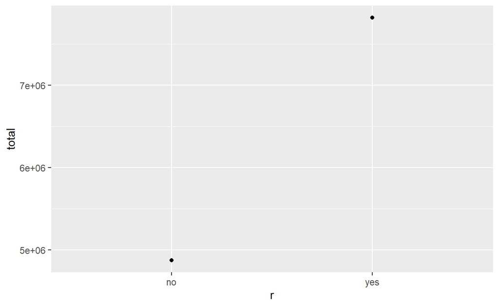

```r
aussie_marriage %>%
  filter(q == "response_clear") %>%
  drop_na() %>%
  group_by(r) %>%
  summarize(r, total = sum(value)) %>%
  distinct() %>%
  ggplot(aes(x=r, y=total)) +
    geom_point()
```

- try an earlier challenge; try a pivot_longer, maybe with eggs data (clean or unclean); read a single sheet of active duty military data; read in hotels data and try grouping and graphing; (advanced) try using couch_db

I did a pivot longer in the previous challenge and in HW2.

```r
ActiveDutyMilitary <- read_excel("_data/Unclean/ActiveDuty_MaritalStatus.xls", sheet = "TotalDoD", skip = 8) %>%
  select(2:4,6,7,9,10,12,13) %>%
  rename(paygrade = 1, "single::yes:male" = 2, "single::yes:female" = 3, "single::no:male" = 4, "single::no:female" = 5, "married:military::male" = 6, "married:military::female" = 7,"married:civilian::male" = 8, "married:civilian::female" = 9) %>%
  filter(str_detect(paygrade, "TOTAL", negate = TRUE)) %>%
  pivot_longer(cols = 2:9, names_to = "temp") %>%
  separate(paygrade, into = c("Class","level"), sep = "-") %>%
  separate(temp, into = c("married","spouse","chidren","gender"), sep = ":")

head(ActiveDutyMilitary)
```

```
# A tibble: 6 x 7
  Class level married spouse     chidren gender value
  <chr> <chr> <chr>   <chr>      <chr>   <chr>  <dbl>
1 E     1     single  ""         "yes"   male   31229
2 E     1     single  ""         "yes"   female  5717
3 E     1     single  ""         "no"    male     563
4 E     1     single  ""         "no"    female   122
5 E     1     married "military" ""      male     139
6 E     1     married "military" ""      female   141
```

- try an earlier challenge; try using transactional data, grouping, and then visualizing grouped statistics; (intermediate) try graphing data with time on the x axis; (advanced) try reading in the active duty military dataset (one sheet only);
- Try an earlier challenge; try using lubridate to transform non-date variables to dates (e.g, in eggs dataset); try using facet_wrap or facet_grid; try reading in a single sheet of active duty military data
- Try an earlier challenge; try to figure out the messy data at https://docs.google.com/spreadsheets/d/1N3FpC8k_0jNiA6uYkFP0JITzxDfh83oGalkRVo9ZBgc/edit#gid=2009914420
- We will work on dates using lubridate in the next session. One challenge would be to try to create a minimal working example to post in a help request.

Distill is a publication format for scientific and technical writing, native to the web.

Learn more about using Distill at https://rstudio.github.io/distill.